# Coastal light pressure

The pressure is the share of a coastal band that is lit, rounded to two decimal places. A 1 km cell counts as lit when its median night-time radiance is above 1 nW cm^-2 sr^-1. That level is about the top of the background in this satellite product, so a cell above it has stable artificial light rather than the faint fringe the mask leaves behind.

The band is scored once per region. It is the land within 1 km of that region’s own marine polygon, plus the sea within 5 km of that region’s own land. Open water farther offshore is left out. It is almost all dark, and including it would pull every region toward zero. The two pieces are built one region at a time, so a narrow channel does not hand one region’s shore to its neighbour. A cell already on the marine grid stays in the marine part of the band.

The measurements are the Earth Observation Group’s annual VIIRS nighttime lights. Earth Engine stores 2013–2021 in collection V2.1 and 2022–2024 in collection V2.2. Both use the median radiance after the background mask. The median drops fires and other one-night flares. Unlit background is stored as zero. Seasonal squid-jigging lights are mostly gone, because they do not last through the year. The 2012 composite is a partial year and is left out.

Several 15 arc-second satellite cells fall inside one 1 km cell. The 1 km value is their average. Zero stays zero: it means unlit, not missing.

```r
library(sf)
library(terra)
library(tidyverse)
library(scales)
library(knitr)
sf_use_s2(FALSE)
```

```
## Spherical geometry (s2) switched off
```

```r
knitr::opts_chunk$set(fig.width = 8, fig.height = 6, message = FALSE, warning = FALSE)

target_crs <- "EPSG:6372"

rgn_path <- "/home/frazier/ohi_goc_prep/spatial/ohi_regions/goc_ohi_rgns.shp"
marine_raster_path <- "/home/frazier/ohi_goc_prep/spatial/ohi_regions/ohi_marine_raster_1km.tif"

raw_dir <- "/home/shares/ohi/OHI_GOC/_raw_data/light_VIIRS"
out_dir <- "/home/frazier/ohi_goc_prep/_pressures/prs_light/output"
fig_dir <- "/home/frazier/ohi_goc_prep/_pressures/prs_light/figures"
dir.create(raw_dir, showWarnings = FALSE, recursive = TRUE)
dir.create(out_dir, showWarnings = FALSE, recursive = TRUE)
dir.create(fig_dir, showWarnings = FALSE, recursive = TRUE)

python_bin <- "/home/frazier/anaconda3/bin/python3"
download_script <- "/home/frazier/ohi_goc_prep/_pressures/prs_light/download_vnl_v22.py"

# Same Cloud project the vessel BigQuery queries bill to.
ee_project <- Sys.getenv("EE_PROJECT", unset = "goc-vms")

years <- 2013:2024
inland_m <- 1000
offshore_m <- 5000
light_cutoff <- 1

rgn_colors <- c(
  "Region 1" = "#C03729",
  "Region 2" = "#E68C7C",
  "Region 3" = "#FC8F24",
  "Region 4" = "#dcaa38",
  "Region 5" = "#cbd2a0",
  "Region 6" = "#98a25a",
  "Region 7" = "#747428",
  "Region 8" = "#627391",
  "Region 9" = "#8d61a9"
)

# Keep polygon pieces and drop lines created where two polygons only touch.
as_polygons <- function(x) {
  x <- st_collection_extract(st_make_valid(x), "POLYGON")
  x[!st_is_empty(x), ]
}

raw_path <- function(year) {
  file.path(raw_dir, sprintf("vnl_v22_median_masked_%d.tif", year))
}

coast_path <- function(year) {
  file.path(out_dir, sprintf("radiance_coast_1km_%d.tif", year))
}
```

## 1. The coastal band

Each region has a land polygon and a marine polygon. The land piece is that region’s land within 1 km of its marine polygon. The sea piece is that region’s sea within 5 km of its land. Raster cells are kept when their centre falls in the piece. A centre that falls in both is kept as sea, because it is already on the marine grid.

```r
regions <- st_read(rgn_path, quiet = TRUE) %>%
  st_make_valid() %>%
  st_transform(target_crs) %>%
  mutate(
    rgn_num = as.integer(str_remove(rgn_id, "Region_")),
    region_label = paste("Region", rgn_num)
  )

land <- regions %>% filter(location == "land")
marine <- regions %>% filter(location == "marine")

# The buffer carries no attributes, so the region id comes from the polygon it is cut to.
inland <- bind_rows(lapply(sort(unique(land$rgn_id)), function(region) {
  shore <- marine %>%
    filter(rgn_id == region) %>%
    select() %>%
    st_buffer(inland_m)
  st_intersection(land %>% filter(rgn_id == region), shore) %>%
    as_polygons()
}))

nearshore <- bind_rows(lapply(sort(unique(marine$rgn_id)), function(region) {
  shore <- land %>%
    filter(rgn_id == region) %>%
    select() %>%
    st_buffer(offshore_m)
  st_intersection(marine %>% filter(rgn_id == region), shore) %>%
    as_polygons()
}))

template <- rast(marine_raster_path)
marine_id <- template

inland_id <- rasterize(vect(inland), template, field = "rgn_num", background = NA)
inland_id <- mask(inland_id, marine_id, inverse = TRUE)

near_id <- rasterize(vect(nearshore), template, field = "rgn_num", background = NA)
near_id <- mask(near_id, marine_id)

coast_id <- cover(inland_id, near_id)

stopifnot(all(na.omit(unique(values(coast_id))) %in% 1:9))

band_km2 <- zonal(ifel(!is.na(coast_id), 1, NA), coast_id, fun = "sum", na.rm = TRUE)
band_km2 <- as_tibble(band_km2)
names(band_km2)[1:2] <- c("rgn_num", "km2")
band_km2 <- band_km2 %>%
  left_join(
    st_drop_geometry(land) %>% distinct(rgn_num, region_label, estado),
    by = "rgn_num"
  ) %>%
  arrange(rgn_num)
```

```r
kable(
  band_km2 %>% select(region_label, estado, km2),
  digits = 0,
  col.names = c("Region", "State", "Cells (km²)"),
  caption = "Cells in the coastal band. Each cell is 1 km². The band is 1 km of land plus 5 km of sea."
)
```

Cells in the coastal band. Each cell is 1 km². The band is 1 km of land plus 5 km of sea.

| Region | State | Cells (km²) |
| --- | --- | --- |
| Region 1 | Baja_California | 508 |
| Region 2 | Baja_California | 5063 |
| Region 3 | Baja_California_Sur | 2542 |
| Region 4 | Baja_California_Sur | 6635 |
| Region 5 | Sonora | 951 |
| Region 6 | Sonora | 4101 |
| Region 7 | Sonora | 3295 |
| Region 8 | Sinaloa | 7066 |
| Region 9 | Nayarit | 3525 |

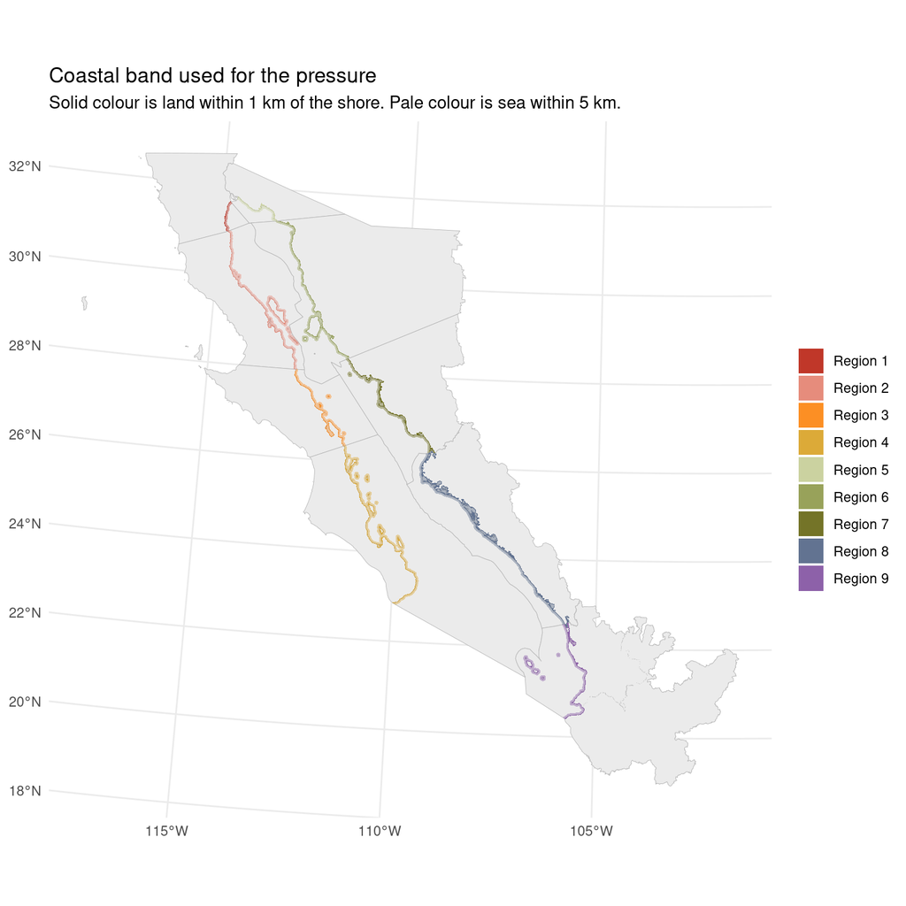

```r
ggplot() +
  geom_sf(data = regions, fill = "grey92", color = "grey70", linewidth = 0.15) +
  geom_sf(data = nearshore, aes(fill = region_label), color = NA, alpha = 0.45) +
  geom_sf(data = inland, aes(fill = region_label), color = NA) +
  scale_fill_manual(values = rgn_colors, name = NULL) +
  labs(
    title = "Coastal band used for the pressure",
    subtitle = "Solid colour is land within 1 km of the shore. Pale colour is sea within 5 km."
  ) +
  theme_minimal() +
  theme(axis.title = element_blank(), legend.position = "right")
```

```r
ggsave(file.path(fig_dir, "light_coastal_band.png"), width = 8, height = 8, bg = "white")
```

## 2. Download the Gulf window

Earth Engine holds 2013–2021 in `NOAA/VIIRS/DNB/ANNUAL_V21` and 2022–2024 in `NOAA/VIIRS/DNB/ANNUAL_V22`. The download asks for `median_masked` inside a rectangle around the OHI regions, with a small margin so the outer coastal cells are not clipped. The northern and southern halves are requested separately and then merged. A year that is already on disk is left as it is.

The first run needs a local Earth Engine login (`earthengine authenticate`) and the Cloud project registered with Earth Engine. Here that project is `goc-vms`.

```r
gulf_bbox_ll <- st_bbox(st_transform(regions, 4326))
pad <- 0.2

missing_years <- years[!file.exists(raw_path(years))]

if (length(missing_years) > 0) {
  status <- system2(
    python_bin,
    args = c(
      download_script,
      "--out-dir", raw_dir,
      "--years", paste(missing_years, collapse = ","),
      "--west", gulf_bbox_ll[["xmin"]] - pad,
      "--south", gulf_bbox_ll[["ymin"]] - pad,
      "--east", gulf_bbox_ll[["xmax"]] + pad,
      "--north", gulf_bbox_ll[["ymax"]] + pad,
      "--project", ee_project
    )
  )
  if (!identical(status, 0L)) {
    stop(
      "The VIIRS download did not finish. Earth Engine has to be signed in on this machine ",
      "(earthengine authenticate), and EE_PROJECT must be the Cloud project registered with Earth Engine."
    )
  }
}

walk(missing_years, function(year) {
  parts <- file.path(raw_dir, sprintf("vnl_v22_median_masked_%d_%s.tif", year, c("s", "n")))
  stopifnot(all(file.exists(parts)))
  merged <- mosaic(sprc(parts), fun = "mean")
  names(merged) <- "median_masked"
  writeRaster(merged, raw_path(year), overwrite = TRUE, datatype = "FLT4S")
  file.remove(parts)
})

raw_check <- tibble(year = years, path = raw_path(years)) %>%
  mutate(
    exists = file.exists(path),
    res_deg = map_dbl(path, ~ res(rast(.x))[1])
  )

# 15 arc-seconds is 0.004167 degrees. Reject a file whose scale was read as degrees.
stopifnot(all(raw_check$exists))
stopifnot(all(raw_check$res_deg > 0.002), all(raw_check$res_deg < 0.02))
raw_check %>% select(year, res_deg)
```

```
## # A tibble: 12 × 2
##     year res_deg
##    <int>   <dbl>
##  1  2013 0.00417
##  2  2014 0.00417
##  3  2015 0.00417
##  4  2016 0.00417
##  5  2017 0.00417
##  6  2018 0.00417
##  7  2019 0.00417
##  8  2020 0.00417
##  9  2021 0.00417
## 10  2022 0.00417
## 11  2023 0.00417
## 12  2024 0.00417
```

## 3. Average each year onto the coastal band

The average is taken first, then the band is applied. Cells outside the band are left empty.

```r
walk(years, function(year) {
  lights <- project(rast(raw_path(year)), template, method = "average")
  lights <- mask(lights, coast_id)
  names(lights) <- "median_masked"
  writeRaster(lights, coast_path(year), overwrite = TRUE, datatype = "FLT4S")
})
```

The colour stretch in the next map is only for display. The stored raster is still the radiance in nW cm^-2 sr^-1. Cells above the cutoff of 1 are the ones that enter the pressure.

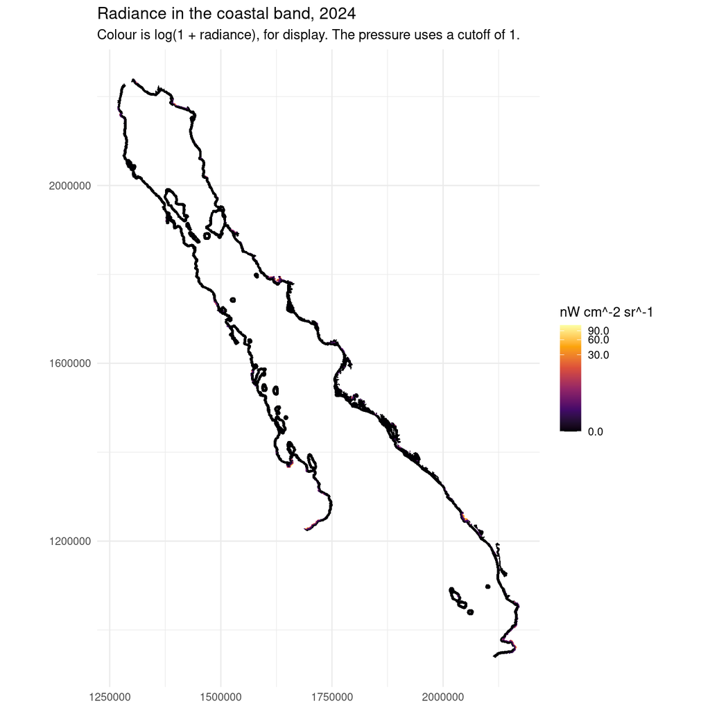

```r
latest <- max(years)

coast_latest <- as.data.frame(rast(coast_path(latest)), xy = TRUE, na.rm = TRUE) %>%
  as_tibble() %>%
  rename(radiance = median_masked) %>%
  mutate(above_cutoff = radiance > light_cutoff)

ggplot(coast_latest, aes(x, y, fill = radiance)) +
  geom_raster() +
  scale_fill_viridis_c(
    option = "inferno",
    trans = "log1p",
    name = "nW cm^-2 sr^-1",
    labels = label_number(accuracy = 0.1)
  ) +
  coord_equal() +
  labs(
    title = sprintf("Radiance in the coastal band, %d", latest),
    subtitle = "Colour is log(1 + radiance), for display. The pressure uses a cutoff of 1."
  ) +
  theme_minimal() +
  theme(axis.title = element_blank())
```

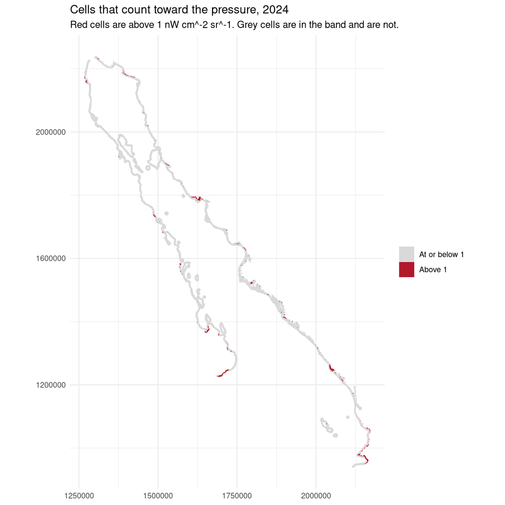

```r
ggplot(coast_latest, aes(x, y, fill = above_cutoff)) +
  geom_raster() +
  scale_fill_manual(
    values = c("TRUE" = "#b2182b", "FALSE" = "grey85"),
    labels = c("TRUE" = "Above 1", "FALSE" = "At or below 1"),
    name = NULL
  ) +
  coord_equal() +
  labs(
    title = sprintf("Cells that count toward the pressure, %d", latest),
    subtitle = "Red cells are above 1 nW cm^-2 sr^-1. Grey cells are in the band and are not."
  ) +
  theme_minimal() +
  theme(axis.title = element_blank())
```

```r
ggsave(
  file.path(fig_dir, "light_coastal_band_above_1_2024.png"),
  width = 8,
  height = 7,
  bg = "white"
)
```

## 4. Pressure

The pressure in a region and year is the number of band cells above 1 divided by the number of band cells. It is already between 0 and 1. Rounding is to two decimal places. Every region is included in every year. A dark coast, such as Region 2, stays at 0.00.

```r
pressure <- map_dfr(years, function(year) {
  lights <- rast(coast_path(year))
  above <- ifel(!is.na(lights), as.numeric(lights > light_cutoff), NA)
  scores <- zonal(above, coast_id, fun = "mean", na.rm = TRUE)
  scores <- as_tibble(scores)
  names(scores)[1:2] <- c("rgn_num", "pressure")
  mutate(scores, year = year)
}) %>%
  left_join(st_drop_geometry(land) %>% distinct(rgn_num, rgn_id), by = "rgn_num") %>%
  transmute(
    rgn_id,
    year,
    pressure = round(pressure, 2)
  ) %>%
  arrange(year, rgn_id)

stopifnot(nrow(pressure) == 9 * length(years))
stopifnot(all(pressure$pressure >= 0), all(pressure$pressure <= 1))

pressure_path <- file.path(out_dir, "light_pressure.csv")
write_csv(pressure, pressure_path)
```

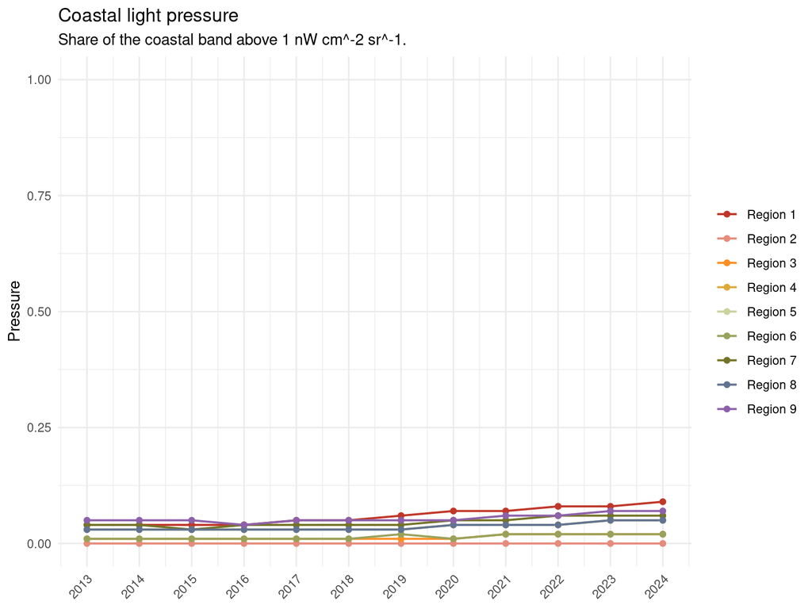

```r
pressure_plot <- pressure %>%
  mutate(region_label = paste("Region", as.integer(str_remove(rgn_id, "Region_")))) %>%
  ggplot(aes(year, pressure, color = region_label)) +
  geom_line(linewidth = 0.7) +
  geom_point(size = 1.6) +
  scale_color_manual(values = rgn_colors, name = NULL) +
  scale_x_continuous(breaks = years) +
  scale_y_continuous(limits = c(0, 1), labels = label_number(accuracy = 0.01)) +
  labs(
    title = "Coastal light pressure",
    subtitle = "Share of the coastal band above 1 nW cm^-2 sr^-1.",
    x = NULL,
    y = "Pressure"
  ) +
  theme_minimal() +
  theme(axis.text.x = element_text(angle = 45, hjust = 1))

pressure_plot
```

```r
ggsave(file.path(fig_dir, "light_pressure.png"), pressure_plot, width = 8, height = 6, bg = "white")
```

```r
kable(
  pressure %>% filter(year == latest),
  digits = 2,
  col.names = c("Region", "Year", "Pressure"),
  caption = sprintf("Pressure in %d, rounded to two decimals.", latest)
)
```

Pressure in 2024, rounded to two decimals.

| Region | Year | Pressure |
| --- | --- | --- |
| Region_1 | 2024 | 0.09 |
| Region_2 | 2024 | 0.00 |
| Region_3 | 2024 | 0.02 |
| Region_4 | 2024 | 0.05 |
| Region_5 | 2024 | 0.05 |
| Region_6 | 2024 | 0.02 |
| Region_7 | 2024 | 0.06 |
| Region_8 | 2024 | 0.05 |
| Region_9 | 2024 | 0.07 |

The pressure table is /home/frazier/ohi_goc_prep/_pressures/prs_light/output/light_pressure.csv. The Gulf windows of the satellite grids are in /home/shares/ohi/OHI_GOC/_raw_data/light_VIIRS.